# Cboomhower_BootstrapRAssignment

Chris Boomhower

June 1, 2016

### Assignment instructions per 2DS Week 4 Homework:

> Write bootstrap code to illustrate the central limit theorem in R markdown and push the result to GitHub. Use a normal distribution with two different sample sizes and an exponential distribution with two different sample sizes. Correct code alone is insufficient. Please also comment on the code and explain the results. For help, see the lotsa.medians function in unit 2. The deliverable is a link to a GitHub repo containing the code.

### Function Description:

#### Two different functions were created to generate random normal and exponential data, to visualize said data, to conduct the bootstrap sampling, and to produce bootstrap mean values’ summary statistics and histogram data. Detailed descriptions of each function are provided in the code comments below.

```r
##########################################################
## Function: sampFunc()
## Inputs:   n == number of sample data to collect
##           nsim == number of bootstrap sample repeats
##           distType == distribution type specifier
## Outputs:  xbar == norm dist. sample mean
##           sdRSample == norm dist. sample standard deviation
##           bootmean == vector of bootstrap sample means
##           (print) --> random sample summary statistics
##           (plots) --> histogram of sample data
##
## Description: Receives number and type of samples to be
##              generated and number of bootstrap samples to
##              collect, produces bootstrap samples, and
##              returns the sample mean, sample standard
##              deviation, and bootstrap sample means.
###########################################################

sampFunc <- function(n, nsim, distType) {

    ## Run conditional statement to collect sample based on normal or exponential distribution
    ## and generate histogram of sample data with correct title
    if(distType == "n") {
        rsample <- rnorm(n, 50, 4)
        hist(rsample, main = paste("RNORM Sample Size of", n), col = "indianred1")
    }
    else if(distType == "e") {
        rsample <- rexp(n)
        hist(rsample, main = paste("REXP Sample Size of", n), col = "indianred1")
    }

    ## Assign sample standard deviation and mean to variables
    sdRSample <- sd(rsample)
    xbar <- mean(rsample)

    ## Print random sample summary results to screen
    cat("Random sample summary statistics:\n")
    print(summary(rsample))

    ## Initialize bootmean vector as numeric type of size 'nsim'
    bootmean <- numeric(nsim)

    ## Run bootstrap sequence and save bootsample means to bootmean vector
    for (i in 1:nsim){
        bootsample <- sample(rsample, size = length(rsample), replace = TRUE)
        bootmean[i] <- mean(bootsample)
    }

    ## Return sample mean, standard deviation, and vector of bootsrap means
    return(c(xbar,sdRSample,bootmean))
}

##########################################################
## Function: analyze()
## Inputs:   N == number of sample data to collect
##           repeats == number of bootstrap sample repeats
##           DistTYPE == distribution type specifier
## Outputs:  (print) --> random sample's summary statistics
##           (print) --> bootstrap sample's summary statistics
##           (print) --> bootstrap sample's standard deviation
##           (print) --> standard error of the sample mean
##           (plots) --> histogram of bootstrap means
##
## Description: Receives number and type of samples to be
##              generated and number of bootstrap samples to
##              collect, and passes these values to the
##              sampFunc() function. Processes sampFunc()
##              returned values and produces bootstrap mean
##              summary statistics, and standard error of
##              the sample mean. Additionally, bootstrap mean
##              histograms are plotted for comparison to sample
##              histograms and random sample's and bootstrap
##              sample's standard deviations are displayed.
###########################################################

analyze <- function(N, repeats, DistTYPE) {

    ## Obtain sample mean, sample sd, and bootstrap mean from random distribution
    funcReturn <- sampFunc(N, repeats, DistTYPE)
    sampleMean <- funcReturn[1]
    sampleSD <- funcReturn[2]
    BOOTMean <- funcReturn[-1:-2]

    ## Print bootstrap mean summary results to screen
    cat("Bootstrap sample's summary statistics:\n")
    print(summary(BOOTMean))

    ## Run conditional statement to print correct histogram
    ## title for normal vs. exponential distribution bootstrap mean data
    if(DistTYPE == distNorm) {
        hist(BOOTMean, main = paste("Bootstrapped RNORM Sample Size of", N),
             xlab = "Bootstrap sample", col = "darkolivegreen1")
    }
    else if(DistTYPE == distExp) {
        hist(BOOTMean, main = paste("Bootstrapped REXP Sample Size of", N),
             xlab = "Bootstrap sample", col = "darkolivegreen1")
    }
    ## Add sample mean and bootstrap mean of means lines for comparison in bootstrap histogram
    abline(v = sampleMean, col = "indianred1", lwd = 2)
    abline(v = mean(BOOTMean), col = "darkgreen", lwd = 2, lty = 3)

    # Print random sample and bootstrap standard deviations and standard error
    print(paste("Random sample's standard deviation =",round(sampleSD,4)))
    print(paste("Bootstrap means' standard deviation =",round(sd(BOOTMean),4)))
    print(paste("Standard error of the sample mean =",round((sampleSD/sqrt(N)),4)))
}
```

### Bootstrapping Setup:

#### I chose to collect sample sizes of 10 and 100 for both random normal and random exponential sampling to get a good look at how very different sample sizes perform when bootstrapped. For bootsrap sample collection, I opted to run 2000 bootstrap samples.

```r
## Initialize variables
repeats <- 2000 # Number of bootstrap samples to collect
distNorm <- "n" # Normal distribution selection
distExp <- "e" # Exponential distribution selection
samp1 <- 100
samp2 <- 10
```

### Normal Distribution Outputs - Sample Size of 100

```
## Random sample summary statistics:
##    Min. 1st Qu.  Median    Mean 3rd Qu.    Max.
##   40.31   47.85   50.41   50.06   52.15   58.20
## Bootstrap sample's summary statistics:
##    Min. 1st Qu.  Median    Mean 3rd Qu.    Max.
##   48.79   49.81   50.06   50.05   50.30   51.23
```

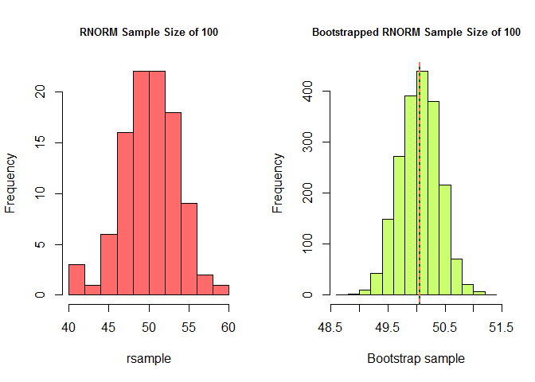

```
## [1] "Random sample's standard deviation = 3.4366"
## [1] "Bootstrap means' standard deviation = 0.3459"
## [1] "Standard error of the sample mean = 0.3437"
```

```r
## Set graphical parameters for histograms
par(mfrow = c(1, 2), cex.main = 0.8)  # 2 rows and 2 columns with title text shrink by 20%

## Normal Distribution 100 Samples - Demonstration of Central Limit Theorem
analyze(samp1, repeats, distNorm)
```

### Normal Distribution Outputs - Sample Size of 10

```
## Random sample summary statistics:
##    Min. 1st Qu.  Median    Mean 3rd Qu.    Max.
##   46.05   47.85   49.74   50.10   52.59   54.88
## Bootstrap sample's summary statistics:
##    Min. 1st Qu.  Median    Mean 3rd Qu.    Max.
##   47.50   49.44   50.11   50.12   50.76   53.49
```

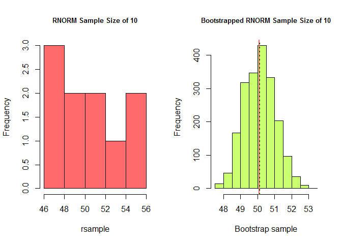

```
## [1] "Random sample's standard deviation = 3.169"
## [1] "Bootstrap means' standard deviation = 0.9227"
## [1] "Standard error of the sample mean = 1.0021"
```

```r
## Set graphical parameters for histograms
par(mfrow = c(1, 2), cex.main = 0.8)  # 2 rows and 2 columns with title text shrink by 20%

## Normal Distribution 10 Samples - Demonstration of Central Limit Theorem
analyze(samp2, repeats, distNorm)
```

### Exponential Distribution Outputs - Sample Size of 100

```
## Random sample summary statistics:
##     Min.  1st Qu.   Median     Mean  3rd Qu.     Max.
## 0.000031 0.270000 0.736900 1.020000 1.537000 4.421000
## Bootstrap sample's summary statistics:
##    Min. 1st Qu.  Median    Mean 3rd Qu.    Max.
##  0.6916  0.9554  1.0170  1.0190  1.0850  1.3530
```

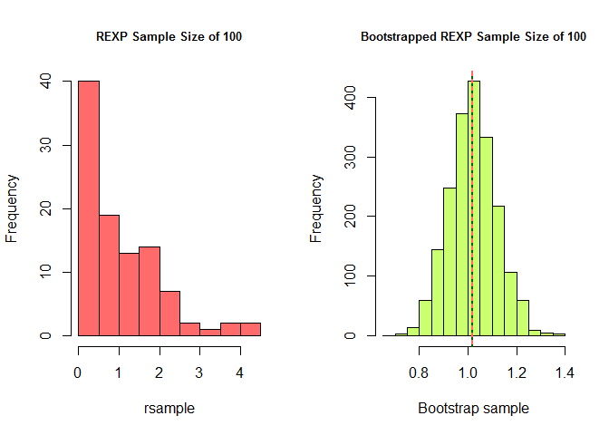

```
## [1] "Random sample's standard deviation = 0.9934"
## [1] "Bootstrap means' standard deviation = 0.0975"
## [1] "Standard error of the sample mean = 0.0993"
```

```r
## Set graphical parameters for histograms
par(mfrow = c(1, 2), cex.main = 0.8)  # 2 rows and 2 columns with title text shrink by 20%

## Exponential Distribution 100 Samples - Demonstration of Central Limit Theorem
analyze(samp1, repeats, distExp)
```

### Exponential Distribution Outputs - Sample Size of 10

```
## Random sample summary statistics:
##    Min. 1st Qu.  Median    Mean 3rd Qu.    Max.
## 0.08366 0.36300 0.93980 0.97740 1.62300 1.93400
## Bootstrap sample's summary statistics:
##    Min. 1st Qu.  Median    Mean 3rd Qu.    Max.
##  0.3176  0.8314  0.9826  0.9795  1.1200  1.7420
```

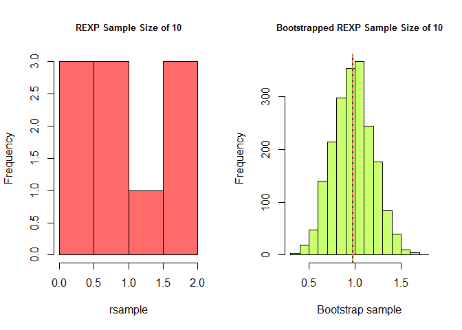

```
## [1] "Random sample's standard deviation = 0.7004"
## [1] "Bootstrap means' standard deviation = 0.2149"
## [1] "Standard error of the sample mean = 0.2215"
```

```r
## Set graphical parameters for histograms
par(mfrow = c(1, 2), cex.main = 0.8)  # 2 rows and 2 columns with title text shrink by 20%

## Exponential Distribution 10 Samples - Demonstration of Central Limit Theorem
analyze(samp2, repeats, distExp)
```